# Feedforward Networks for Handwritten Digit Recognition

In this assignment you will learn how to use feedforward neural networks to solve a classical task in machine learning: handwritten digit recognition using images from the [MNIST dataset](http://yann.lecun.com/exdb/mnist/). More concretely, you will have to solve the following tasks:

1. implement a deep feedforward network that reads a batch of images and predicts the corresponding digits
2. train this network using stochastic gradient descent

In order to run the code for this assignment, you need a working installation of [NumPy](http://www.numpy.org). Check whether everything works by running the following code cell:

```python
import numpy as np
```

## Data

The MNIST dataset is split into a training set with 60,000 instances and a test set with 10,000 instances. Each instance consists of a greyscale image of a handwritten digit and an integer representing the digit in the image, as labelled by human experts. The digits are scaled and centred on a 28-by-28 pixel canvas. Here are some examples of how the images can look like:

[figure not shown]

The following code will read the training data and the test data:

```python
import mnist_network

training_x, training_y = mnist_network.read_training_data()
print('Shapes of the training data matrices: {} {}'.format(training_x.shape, training_y.shape))

test_x, test_y = mnist_network.read_test_data()
print('Shapes of the test data matrices: {} {}'.format(test_x.shape, test_y.shape))
```

```
Shapes of the training data matrices: (60000, 784) (60000, 10)
Shapes of the test data matrices: (10000, 784) (10000, 10)
```

From a Python perspective, each of the two data sets is a pair `(x, y)` of matrices: Each row of `x` is a 784-component vector containing the greyscale values of the pixels in an image as floats between 0 and 1. Each row of `y` is a 10-component one-hot vector representing the digit corresponding to the image. As an example, here is the vector for the first digit in the test data, the digit 7:

```python
test_y[0]
```

```
array([0., 0., 0., 0., 0., 0., 0., 1., 0., 0.])
```

## Task 1: Implement the network

Your first task is to implement a deep feedforward network that reads a batch of image vectors and predicts the corresponding digits. Your network should conform to the following specification:

- one input layer, one output layer, flexible number of hidden layers
- activation function for hidden layers: rectified linear unit (ReLU)
- activation function for output layer: softmax
- error function for gradient computation: categorical cross-entropy

To get you started on this task, we provide skeleton code and a number of useful helper functions.

### Helper functions

The following cell contains NumPy-based implementations of the ReLU activation function and its derivative (which you should use for the hidden layers of your network), as well as the softmax activation function (for the output layer).

```python
def relu(x):
    return x * (x > 0)

def relu_prime(x):
    return 1 * (x > 0)

def softmax(x):
    e_x = np.exp(x - np.max(x, axis=1, keepdims=True))
    return e_x / e_x.sum(axis=1, keepdims=True)
```

In each case, the argument `x` is a batch of input values, such as `training_x`. The implementation of the softmax function uses a standard trick to improve numerical stability; see [this link](http://stackoverflow.com/questions/34968722/softmax-function-python) for more information.

### Skeleton code

To get you started, we provide the following skeleton code:

```python
class Network():

    def __init__(self, sizes):
        self.ws = [np.random.randn(m,n) / np.sqrt(n / 2) for m, n in zip(sizes[:-1], sizes[1:])]
        self.bs = [np.zeros((1, n)) for n in sizes[1:]]
        self.hidden_layer_num = len(sizes) - 2
        self.net_size = sizes
        # for optimization
        self.ws_m = [np.zeros((m, n)) for m, n in zip(sizes[:-1], sizes[1:])]
        self.ws_v = [np.zeros((m, n)) for m, n in zip(sizes[:-1], sizes[1:])]
        self.bs_m = [np.zeros((1, n)) for n in sizes[1:]]
        self.bs_v = [np.zeros((1, n)) for n in sizes[1:]]

    def forward(self, x):
        unit_output = []
        unit_output.append(x)
        weigthed_sum = []
        for i in range(self.hidden_layer_num):
            unit_output.append(relu(np.dot(x, self.ws[i]) + self.bs[i]))
            weigthed_sum.append(np.dot(x, self.ws[i]) + self.bs[i])
            x = relu(np.dot(x, self.ws[i]) + self.bs[i])
        x = softmax(np.dot(x, self.ws[-1]) + self.bs[-1])
        return x, unit_output, weigthed_sum

    def predict(self, x):
        prediction = self.forward(x)[0]
        return np.argmax(prediction, axis = 1)

    def update_weight(self, weight, lr, delta, y, i, opt_option = 0):
        if opt_option is 0:
            #without optimization
            gradient = np.dot(y, delta)
            return weight - lr * gradient
        elif opt_option is 1:
            #Adam
            rho_1 = 0.9
            rho_2 = 0.999
            epsilon = 1e-8
            gradient = np.dot(y, delta)
            #update biased first moment estimate
            self.ws_m[i] = rho_1 * self.ws_m[i] + (1 - rho_1) * gradient
            #update biased second moment estimate
            self.ws_v[i] = rho_2 * self.ws_v[i] + (1 - rho_2) * gradient * gradient
            #correct bias in first moment
            hidden_s = self.ws_m[i] / (1 - pow(rho_1, i + 1))
            #correct bias in seccond moment
            hidden_r = self.ws_v[i] / (1 - pow(rho_2, i + 1))
            return weight - lr * hidden_s / (np.sqrt(hidden_r) + epsilon)


    def update_bias(self, bias, lr, delta, i, opt_option = 0):
        #either sum or averaged
        if opt_option is 0:
            #without optimization
            gradient = delta.sum(axis = 0, keepdims = True)
            return bias - lr * gradient
        elif opt_option is 1:
            #Adam
            rho_1 = 0.9
            rho_2 = 0.999
            epsilon = 1e-8
            gradient = delta.sum(axis = 0, keepdims = True)
            #update biased first moment estimate
            self.bs_m[i] = rho_1 * self.bs_m[i] + (1 - rho_1) * gradient
            #update biased second moment estimate
            self.bs_v[i] = rho_2 * self.bs_v[i] + (1 - rho_2) * gradient * gradient
            #correct bias in first moment
            hidden_s = self.bs_m[i] / (1 - pow(rho_1, i + 1))
            #correct bias in seccond moment
            hidden_r = self.bs_v[i] / (1 - pow(rho_2, i + 1))
            return bias - lr * hidden_s / (np.sqrt(hidden_r) + epsilon)

    #compact calculation
    #Refer to https://deepnotes.io/softmax-crossentropy
    def delta_cross_entropy(self, X, y):
        #get the exact digit that the vector represents that will be used as index later
        y = np.argmax(y, axis = 1)
        #size of mini batch
        m = y.shape[0]
        grad = X
        #yi-ti, ti is always 1 as it represents the probablity for the expected digit
        grad[range(m), y] -= 1
        grad = grad/m
        return grad

    def backpropagate(self, x, y, lr = 1e-3, optimizer = 0):
        forward_output, unit_output, weighted_sum = self.forward(x)
        delta = self.delta_cross_entropy(forward_output, y)
        output_index = self.hidden_layer_num
        #update output layer's weights and bias
        self.ws[output_index] = self.update_weight(self.ws[output_index], lr, delta, unit_output[output_index].T, output_index, optimizer)
        self.bs[output_index] = self.update_bias(self.bs[output_index], lr, delta, output_index, optimizer)
        #update hidden layers' weights and bias
        for i in range(self.hidden_layer_num, 0, -1):
            hidden_derviate = relu_prime(weighted_sum[i-1])
            delta = hidden_derviate * np.dot(delta, self.ws[i].T)
            self.ws[i-1] = self.update_weight(self.ws[i-1], lr, delta, unit_output[i-1].T, i-1, optimizer)
            self.bs[i-1] = self.update_bias(self.bs[i-1], lr, delta, i-1, optimizer)

    def get_net_size(self):
        return self.net_size
```

This code defines a class Network that represents deep feedforward networks. The intended behaviour of the fields and methods of this class is specified below. In the skeleton code, all fields are initialized with, and all methods return, zero matrices of the appropriate shape. In order to obtain a network that meets the requirements, you will have to write code that replaces these placeholders with meaningful values.

In your implementation, you may choose to add more fields and/or methods than the ones included in the skeleton code. However, in all of your code, you may only call functions from the NumPy library, but no other library.

### Fields

**sizes : list(int)**

The dimensions of the network layers, from the first (input) layer to the last (output) layer.

An example, in a network with 784 units in the input layer, 10 units in the output layer, and 100 units in the (single) hidden layer this field would have the value

```python
[784, 100, 10]
```

```
[784, 100, 10]
```

###### **ws : list(np.array)**

The weight matrices of the network, where the matrix at index $i$ holds the weights of the connections from layer $i$ to layer $i+1$. As an example, if the width of layer 0 is $784$ and the width of layer 1 is $100$, then `ws[0]` will have shape $(784, 100)$.

**bs : list(np.array)**

The bias vectors of the network, where the vector at index $i$ holds the biases for layer $i+1$. As an example, `bs[0]` is the bias vector of layer 1. Note that there are no biases for the input layer (layer 0).

### Initialization

Initialize the weights and biases of the network. Note that in the starter code, both weights and biases are initialized using zeros.

**sizes : list(int)**

The dimensions of the network layers, from the first (input) layer to the last (output) layer.

As an example, the following code creates a network with 784 units in the input layer, 10 units in the output layer, and 100 units in the (single) hidden layer:

```python
net = Network([784, 100, 10])
```

### forward

Computes the output of the network for a batch of input values.

**x : np.array**

A batch of input values, such as `training_x`.

**Returns:** The output of the network for the specified input. This will be an array of shape $(m, n)$ where $m$ is the number of rows in the input batch, and $n$ is the size of the last layer in the network. In the starter code, the method returns an array of all zeros.

### predict

Predicts the digits for a batch of input values.

**x : np.array**

A batch of input values, such as `test_x`.

**Returns:** The digits predicted for the specified input. This will be an array of shape $(m, 1)$ where $m$ is the number of rows in the input batch $x$. In the starter code, the method returns an array of all zeros.

### backpropagate

Computes the network gradients for a batch of input and corresponding output values. Note that in the context of this assignment, the gradients should be computed relative to categorical cross-entropy as the error function.

**x : np.array**

A batch of input values, such as `training_x`.

**y : np.array**

A batch of corresponding output values, such as `training_y`.

**Returns:** A list of pairs of the form $(\nabla w, \nabla b)$, one for each non-input layer of the network, where the first component of each pair is the average gradient for the weights of the connections coming into the layer and the second component is the average gradient for the biases at the layer. In the starter code, the method returns a list of zero gradients.

## Task 2: Train your network

Once you have completed the Network class, your second task is to write code to train the network using stochastic gradient descent (SGD).

### Helper functions

The function in the next code cell will sample minibatches from an array `x` of input values and a corresponding array `y` of output values:

```python
def minibatches(x, y, batch_size):
    random_indices = np.random.permutation(np.arange(x.shape[0]))
    for i in range(0, x.shape[0] - batch_size + 1, batch_size):
        batch_indices = random_indices[i:i+batch_size]
        yield x[batch_indices], y[batch_indices]
```

The next function computes the test error rate of a network on a batch of test data.

```python
def evaluate(net):
    return np.mean(net.predict(test_x) != np.argmax(test_y, axis=1))
```

### Skeleton code

The following cell contains skeleton code for the training algorithm.

```python
def train_sgd(net, x, y, n_epochs, batch_size, eta=1e-3, optimizer = 0):
    error_rate_list = list()
    for t in range(n_epochs):
        for batch_x, batch_y in minibatches(x, y, batch_size):
            net.backpropagate(batch_x, batch_y, eta, optimizer)
        error_rate = evaluate(net)
        error_rate_list.append(error_rate)
        print("epoch = {}, test error rate = {:.4f}".format(t, error_rate))
    # for later visualization
    result_summary.append((str(net.get_net_size()) + '-' + str(batch_size) + '-' +str(eta) + '-' +str(optimizer), error_rate_list))
```

The intended meaning of the various parameters is as follows:

**x : np.array**

A batch of input values, such as `training_x`.

**y : np.array**

A batch of corresponding output values, such as `training_y`.

**n_epochs : int**

The number of iterations over the training data (‘epochs’).

**batch_size : int**

The number of input values per minibatch.

**eta : float**

The learning rate in the stochastic gradient descent update step.

### Intended usage

To see how the training code is intended to be used, here is how you set up a network and train it on the training data for 2 iterations with minibatch size 30 and the default learning rate.

```python
result_summary = list()
```

```python
net = Network([784, 1500, 10])
train_sgd(net, training_x, training_y, 10, 50, 1e-2, 0)
```

```
epoch = 0, test error rate = 0.0459
epoch = 1, test error rate = 0.0335
epoch = 2, test error rate = 0.0317
epoch = 3, test error rate = 0.0302
epoch = 4, test error rate = 0.0260
epoch = 5, test error rate = 0.0257
epoch = 6, test error rate = 0.0238
epoch = 7, test error rate = 0.0235
epoch = 8, test error rate = 0.0216
epoch = 9, test error rate = 0.0229
```

```python
net = Network([784, 500, 10])
train_sgd(net, training_x, training_y, 10, 5, 1e-2, 0)
```

```
epoch = 0, test error rate = 0.0430
epoch = 1, test error rate = 0.0245
epoch = 2, test error rate = 0.0269
epoch = 3, test error rate = 0.0221
epoch = 4, test error rate = 0.0212
epoch = 5, test error rate = 0.0210
epoch = 6, test error rate = 0.0201
epoch = 7, test error rate = 0.0211
epoch = 8, test error rate = 0.0194
epoch = 9, test error rate = 0.0199
```

**The above network does not use Adam optimization. Following runnings use Adam optimization.**

```python
net = Network([784, 1500, 10])
train_sgd(net, training_x, training_y, 10, 50, 1e-3, 1)
```

```
epoch = 0, test error rate = 0.0292
epoch = 1, test error rate = 0.0304
epoch = 2, test error rate = 0.0249
epoch = 3, test error rate = 0.0249
epoch = 4, test error rate = 0.0233
epoch = 5, test error rate = 0.0211
epoch = 6, test error rate = 0.0224
epoch = 7, test error rate = 0.0208
epoch = 8, test error rate = 0.0235
epoch = 9, test error rate = 0.0190
```

```python
net = Network([784, 1500, 10])
train_sgd(net, training_x, training_y, 10, 100, 1e-3, 1)
```

```
epoch = 0, test error rate = 0.0286
epoch = 1, test error rate = 0.0262
epoch = 2, test error rate = 0.0251
epoch = 3, test error rate = 0.0201
epoch = 4, test error rate = 0.0208
epoch = 5, test error rate = 0.0221
epoch = 6, test error rate = 0.0189
epoch = 7, test error rate = 0.0211
epoch = 8, test error rate = 0.0278
epoch = 9, test error rate = 0.0233
```

```python
net = Network([784, 1500, 10])
train_sgd(net, training_x, training_y, 10, 200, 1e-3, 1)
```

```
epoch = 0, test error rate = 0.0403
epoch = 1, test error rate = 0.0261
epoch = 2, test error rate = 0.0232
epoch = 3, test error rate = 0.0233
epoch = 4, test error rate = 0.0204
epoch = 5, test error rate = 0.0199
epoch = 6, test error rate = 0.0195
epoch = 7, test error rate = 0.0203
epoch = 8, test error rate = 0.0196
epoch = 9, test error rate = 0.0185
```

```python
net = Network([784, 1000,800, 10])
train_sgd(net, training_x, training_y, 10, 200, 1e-3, 1)
```

```
epoch = 0, test error rate = 0.0370
epoch = 1, test error rate = 0.0286
epoch = 2, test error rate = 0.0271
epoch = 3, test error rate = 0.0223
epoch = 4, test error rate = 0.0208
epoch = 5, test error rate = 0.0204
epoch = 6, test error rate = 0.0206
epoch = 7, test error rate = 0.0197
epoch = 8, test error rate = 0.0187
epoch = 9, test error rate = 0.0187
```

```python
net = Network([784, 1000,1000, 10])
train_sgd(net, training_x, training_y, 10, 200, 1e-3, 1)
```

```
epoch = 0, test error rate = 0.0337
epoch = 1, test error rate = 0.0249
epoch = 2, test error rate = 0.0238
epoch = 3, test error rate = 0.0191
epoch = 4, test error rate = 0.0203
epoch = 5, test error rate = 0.0186
epoch = 6, test error rate = 0.0180
epoch = 7, test error rate = 0.0190
epoch = 8, test error rate = 0.0175
epoch = 9, test error rate = 0.0182
```

```python
net = Network([784, 1000,1000, 10])
train_sgd(net, training_x, training_y, 10, 500, 1e-3, 1)
```

```
epoch = 0, test error rate = 0.0436
epoch = 1, test error rate = 0.0354
epoch = 2, test error rate = 0.0302
epoch = 3, test error rate = 0.0238
epoch = 4, test error rate = 0.0270
epoch = 5, test error rate = 0.0234
epoch = 6, test error rate = 0.0227
epoch = 7, test error rate = 0.0223
epoch = 8, test error rate = 0.0224
epoch = 9, test error rate = 0.0211
```

```python
net = Network([784, 1000,500, 10])
train_sgd(net, training_x, training_y, 10, 500, 1e-3, 1)
```

```
epoch = 0, test error rate = 0.0451
epoch = 1, test error rate = 0.0338
epoch = 2, test error rate = 0.0286
epoch = 3, test error rate = 0.0270
epoch = 4, test error rate = 0.0215
epoch = 5, test error rate = 0.0226
epoch = 6, test error rate = 0.0217
epoch = 7, test error rate = 0.0206
epoch = 8, test error rate = 0.0194
epoch = 9, test error rate = 0.0200
```

```python
net = Network([784, 1000,500, 10])
train_sgd(net, training_x, training_y, 10, 200, 1e-3, 1)
```

```
epoch = 0, test error rate = 0.0330
epoch = 1, test error rate = 0.0271
epoch = 2, test error rate = 0.0234
epoch = 3, test error rate = 0.0213
epoch = 4, test error rate = 0.0194
epoch = 5, test error rate = 0.0189
epoch = 6, test error rate = 0.0180
epoch = 7, test error rate = 0.0174
epoch = 8, test error rate = 0.0211
epoch = 9, test error rate = 0.0170
```

```python
net = Network([784, 500,1000,500, 10])
train_sgd(net, training_x, training_y, 10, 200, 1e-3, 1)
```

```
epoch = 0, test error rate = 0.0345
epoch = 1, test error rate = 0.0311
epoch = 2, test error rate = 0.0245
epoch = 3, test error rate = 0.0228
epoch = 4, test error rate = 0.0232
epoch = 5, test error rate = 0.0237
epoch = 6, test error rate = 0.0206
epoch = 7, test error rate = 0.0200
epoch = 8, test error rate = 0.0196
epoch = 9, test error rate = 0.0191
```

```python
net = Network([784, 500,1000,500, 10])
train_sgd(net, training_x, training_y, 10, 100, 1e-3, 1)
```

```
epoch = 0, test error rate = 0.0360
epoch = 1, test error rate = 0.0272
epoch = 2, test error rate = 0.0226
epoch = 3, test error rate = 0.0225
epoch = 4, test error rate = 0.0241
epoch = 5, test error rate = 0.0276
epoch = 6, test error rate = 0.0226
epoch = 7, test error rate = 0.0242
epoch = 8, test error rate = 0.0194
epoch = 9, test error rate = 0.0260
```

```python
net = Network([784, 1000,800,600, 10])
train_sgd(net, training_x, training_y, 10, 200, 1e-3, 1)
```

```
epoch = 0, test error rate = 0.0339
epoch = 1, test error rate = 0.0309
epoch = 2, test error rate = 0.0224
epoch = 3, test error rate = 0.0221
epoch = 4, test error rate = 0.0223
epoch = 5, test error rate = 0.0186
epoch = 6, test error rate = 0.0190
epoch = 7, test error rate = 0.0226
epoch = 8, test error rate = 0.0274
epoch = 9, test error rate = 0.0211
```

```python
net = Network([784, 1000,800,600, 10])
train_sgd(net, training_x, training_y, 10, 500, 1e-3, 1)
```

```
epoch = 0, test error rate = 0.0450
epoch = 1, test error rate = 0.0332
epoch = 2, test error rate = 0.0295
epoch = 3, test error rate = 0.0264
epoch = 4, test error rate = 0.0256
epoch = 5, test error rate = 0.0241
epoch = 6, test error rate = 0.0227
epoch = 7, test error rate = 0.0221
epoch = 8, test error rate = 0.0216
epoch = 9, test error rate = 0.0208
```

### Performance goal

Once you have a working network and training algorithm, you can compare the error rate of your network to the results on the [MNIST website](http://yann.lecun.com/exdb/mnist/).

**To get credit for this assignment, your network must achieve a test error rate of less than 2% at least once during the first 10 epochs of training.**

To tune your network, you can play around with the various training parameters: number of epochs, minibatch size, and learning rate. In addition to that, you can also make more substantial changes such as the following:

- Make the network wider (increase the size of a layer) or deeper (add more layers).
- Implement a different initialization strategy.
- Implement a regularization method or dropout.
- Implement an optimization algorithm with an adaptive learning rate, such as RMSProp or Adam.

## How to submit

When you have reached the performance goal, send this notebook to Marco to receive credit for the assignment. The notebook must be self-contained and must run without error.

In addition to your code, you are asked to submit a short text (less than 500 words) in which you reflect on what you have done. Which specific choices did you make when tuning your network? How did these choices affect performance? You can enter your text in the cell below.

### Report

I started to program for this lab several days before the first lecture. I just initialized the weights and bias as zero. So the result at the beginning had a very higher error rate. After I read the slides of the first lecture and chapters 6 to 8, I realized that such initialization for weights was not reasonable, and perhaps I also need to make use of an optimization algorithm, so I referred to a normalized initialization for weights (He et al. (2016)). Such normalized initialization helps a lot. The error rate of the net decreased to less than 2% with only one hidden layer.

Then I try to increase the number of hidden layers into 2 to ensure the whole code is correct and to meet the performance goal of this lab. However, after several steps in training, the 'divide by zero' problem happens. I found the weights go to extremely high during the training, which could be the result of gradient explosion or maybe just other errors in my code. I realized that I should use an optimized approach. I used the Adam optimization method, and it improves the net's accuracy. For examples, a net with a 1500 units' hidden layer(trained with 200 batch), a net including 2 hidden layers with 1000 units and 800 units respectively(trained with 200 batch), and a net including 3 hidden layers with 500 units, 1000 units, 500 units (trained with 200 batch) give the error rate less than 2%.

For the results of Neural Nets'methods from the MNIST website, it seems that elastic distortions contribute so much to decrease the error rate in the Neural Nets based methods. I think elastic distortion is commonly used in such image recognization applications as it enables the network to be more generalized.

### To visualize

Visualize the results from serveral runnings.

```python
import matplotlib.pyplot as plt
def visualize(result):
    epoch = [1, 2, 3, 4, 5, 6, 7, 8, 9, 10]
    baseline = [0.02,0.02,0.02,0.02,0.02,0.02,0.02,0.02,0.02,0.02]
    plt.figure(figsize=(20,20))
    plt.plot(epoch, baseline, label = 'baseline')
    for record in result:
        plt.plot (epoch, record[1],label = record[0])
        plt.xlabel('Epoch')
        plt.ylabel('Error Rate')

        plt.title("Summary of the result")

        plt.legend()
    plt.show()
```

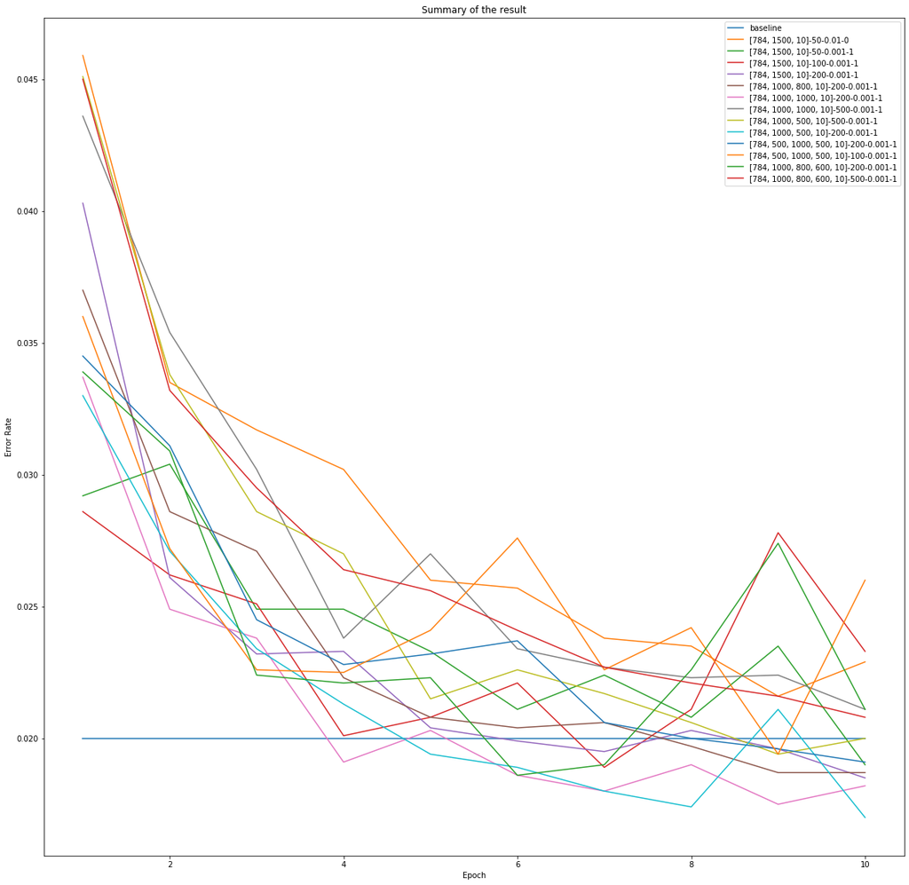

```python
visualize(result_summary)
```

*Good luck!*